# **Kickstarter Project Analysis**

## **Abstract:**

This research is dedicated to unraveling the mystery of Kickstarter project success, with a primary focus on discerning the pivotal factors that contribute to project triumph. The dataset comprises essential variables such as project category, currency, deadline, launch timing, funding goal in native currency, pledged amounts in native currency, project state (success or failure), backer count, project location, USD pledged, and the actual USD goal.

Central to our investigation is the project 'state' variable, serving as the label for our predictive analysis. Our **primary** goal is to develop a predictive model that accurately anticipates the success or failure of Kickstarter projects. By leveraging machine learning techniques, we aim to identify the underlying patterns and dependencies among the provided variables that significantly impact project outcomes.

The findings of this study hold significant implications for project creators, backers, and the crowdfunding community, offering actionable insights into the recipe for Kickstarter success. A successful predictive model can empower stakeholders to make informed decisions, optimize project planning, and enhance the overall effectiveness of crowdfunding initiatives, fostering a more resilient and prosperous crowdfunding landscape.

## Read the Data

```python
pip install pycountry
```

```python
pip install datasist
```

```python
import pandas as pd
import matplotlib.pyplot as plt
import seaborn as sns
import numpy as np

from sklearn.linear_model import LogisticRegression
from sklearn.preprocessing import StandardScaler
from sklearn.model_selection import train_test_split
from sklearn.metrics import accuracy_score, roc_auc_score
from sklearn.tree import DecisionTreeClassifier, plot_tree

import pycountry
from datasist.structdata import detect_outliers
```

```python
df = pd.read_csv('ks2.csv')
```

```python
df = df.drop(['ID', 'name'], axis=1)
```

We drop identifiers 'ID' and 'name'

```python
df.head(5)
```

|  | category | main_category | currency | deadline | goal | launched | pledged | state | backers | country | usd pledged | usd_pledged_real | usd_goal_real |
| --- | --- | --- | --- | --- | --- | --- | --- | --- | --- | --- | --- | --- | --- |
| 0 | Poetry | Publishing | GBP | 2015-10-09 | 1000.0 | 2015-08-11 12:12:28 | 0.0 | failed | 0 | GB | 0.0 | 0.0 | 1533.95 |
| 1 | Narrative Film | Film & Video | USD | 2017-11-01 | 30000.0 | 2017-09-02 04:43:57 | 2421.0 | failed | 15 | US | 100.0 | 2421.0 | 30000.00 |
| 2 | Narrative Film | Film & Video | USD | 2013-02-26 | 45000.0 | 2013-01-12 00:20:50 | 220.0 | failed | 3 | US | 220.0 | 220.0 | 45000.00 |
| 3 | Music | Music | USD | 2012-04-16 | 5000.0 | 2012-03-17 03:24:11 | 1.0 | failed | 1 | US | 1.0 | 1.0 | 5000.00 |
| 4 | Film & Video | Film & Video | USD | 2015-08-29 | 19500.0 | 2015-07-04 08:35:03 | 1283.0 | canceled | 14 | US | 1283.0 | 1283.0 | 19500.00 |

```python
df.dtypes
```

[output not shown]

## We get rid of country labels and replace them with country name for extra clarity

```python
def get_country_name(code):
    country = pycountry.countries.get(alpha_2=code)
    if country:
        return country.name
    else:
        return "NA"
```

```python
df['country'] = df['country'].apply(lambda x: get_country_name(x))
```

```python
df['country'].value_counts()
```

```
United States     292627
United Kingdom     33672
Canada             14756
Australia           7839
Germany             4171
NA                  3797
France              2939
Italy               2878
Netherlands         2868
Spain               2276
Sweden              1757
Mexico              1752
New Zealand         1447
Denmark             1113
Ireland              811
Switzerland          761
Norway               708
Hong Kong            618
Belgium              617
Austria              597
Singapore            555
Luxembourg            62
Japan                 40
Name: country, dtype: int64
```

```python
df = df[df['country'] != 'NA']
```

```python
df.shape
```

[output not shown]

## We change "launched" and "deadline" to date format then create a duration in **DAYS**

```python
df['launched'] = pd.to_datetime(df['launched'])
df['deadline'] = pd.to_datetime(df['deadline'])
```

```python
df = df.assign(day_launched=df.launched.dt.day, month_launched=df.launched.dt.month,year_launched=df.launched.dt.year)
```

```python
df['project_duration_days'] = (df['deadline'] - df['launched']).dt.days
```

```python
df['Duration'] = df['project_duration_days']
```

```python
df.drop(['project_duration_days'],axis=1)
```

|  | category | main_category | currency | deadline | goal | launched | pledged | state | backers | country | usd pledged | usd_pledged_real | usd_goal_real | day_launched | month_launched | year_launched | Duration |
| --- | --- | --- | --- | --- | --- | --- | --- | --- | --- | --- | --- | --- | --- | --- | --- | --- | --- |
| 0 | Poetry | Publishing | GBP | 2015-10-09 | 1000.0 | 2015-08-11 12:12:28 | 0.0 | failed | 0 | United Kingdom | 0.0 | 0.0 | 1533.95 | 11 | 8 | 2015 | 58 |
| 1 | Narrative Film | Film & Video | USD | 2017-11-01 | 30000.0 | 2017-09-02 04:43:57 | 2421.0 | failed | 15 | United States | 100.0 | 2421.0 | 30000.00 | 2 | 9 | 2017 | 59 |
| 2 | Narrative Film | Film & Video | USD | 2013-02-26 | 45000.0 | 2013-01-12 00:20:50 | 220.0 | failed | 3 | United States | 220.0 | 220.0 | 45000.00 | 12 | 1 | 2013 | 44 |
| 3 | Music | Music | USD | 2012-04-16 | 5000.0 | 2012-03-17 03:24:11 | 1.0 | failed | 1 | United States | 1.0 | 1.0 | 5000.00 | 17 | 3 | 2012 | 29 |
| 4 | Film & Video | Film & Video | USD | 2015-08-29 | 19500.0 | 2015-07-04 08:35:03 | 1283.0 | canceled | 14 | United States | 1283.0 | 1283.0 | 19500.00 | 4 | 7 | 2015 | 55 |
| ... | ... | ... | ... | ... | ... | ... | ... | ... | ... | ... | ... | ... | ... | ... | ... | ... | ... |
| 378656 | Documentary | Film & Video | USD | 2014-10-17 | 50000.0 | 2014-09-17 02:35:30 | 25.0 | canceled | 1 | United States | 25.0 | 25.0 | 50000.00 | 17 | 9 | 2014 | 29 |
| 378657 | Narrative Film | Film & Video | USD | 2011-07-19 | 1500.0 | 2011-06-22 03:35:14 | 155.0 | failed | 5 | United States | 155.0 | 155.0 | 1500.00 | 22 | 6 | 2011 | 26 |
| 378658 | Narrative Film | Film & Video | USD | 2010-08-16 | 15000.0 | 2010-07-01 19:40:30 | 20.0 | failed | 1 | United States | 20.0 | 20.0 | 15000.00 | 1 | 7 | 2010 | 45 |
| 378659 | Technology | Technology | USD | 2016-02-13 | 15000.0 | 2016-01-13 18:13:53 | 200.0 | failed | 6 | United States | 200.0 | 200.0 | 15000.00 | 13 | 1 | 2016 | 30 |
| 378660 | Performance Art | Art | USD | 2011-08-16 | 2000.0 | 2011-07-19 09:07:47 | 524.0 | failed | 17 | United States | 524.0 | 524.0 | 2000.00 | 19 | 7 | 2011 | 27 |

374864 rows × 17 columns

## Let's explore our label (state)

```python
df['state'].value_counts()
```

```
failed        197614
successful    133851
canceled       38757
live            2798
suspended       1844
Name: state, dtype: int64
```

```python
desired_states = ['successful', 'failed']
df = df[df['state'].isin(desired_states)]
```

```python
df['state'].value_counts()
```

```
failed        197614
successful    133851
Name: state, dtype: int64
```

*Our main focus will be on "successful" and "failed", while "live", "suspended", "canceled" and "undefined" will be removed because they are ambiguous and represent a small portion of our dataset*

## Let's explore the other variables and define our features

```python
df['main_category'].value_counts()
```

```
Film & Video    56504
Music           45801
Publishing      35413
Games           28521
Technology      27046
Art             25641
Design          25363
Food            22054
Fashion         19774
Theater         10242
Comics           9878
Photography      9689
Crafts           7818
Journalism       4148
Dance            3573
Name: main_category, dtype: int64
```

```python
df['category'].value_counts()
```

[output not shown]

```python
df['currency'].value_counts()
```

```
USD    261360
GBP     29454
EUR     14357
CAD     12370
AUD      6616
SEK      1509
MXN      1411
NZD      1274
DKK       926
CHF       652
NOK       582
HKD       477
SGD       454
JPY        23
Name: currency, dtype: int64
```

*Most our data uses 'USD' as the native currency.*

```python
df['goal'].mean()
```

```
44266.13981823119
```

```python
df['goal'].median()
```

```
5000.0
```

```python
df['goal'].describe()
```

```
count    3.314650e+05
mean     4.426614e+04
std      1.118264e+06
min      1.000000e-02
25%      2.000000e+03
50%      5.000000e+03
75%      1.500000e+04
max      1.000000e+08
Name: goal, dtype: float64
```

```python
df['goal'].min()
```

```
0.01
```

```python
df['goal'].max()
```

```
100000000.0
```

```python
df.dtypes
```

```
category                         object
main_category                    object
currency                         object
deadline                 datetime64[ns]
goal                            float64
launched                 datetime64[ns]
pledged                         float64
state                            object
backers                           int64
country                          object
usd pledged                     float64
usd_pledged_real                float64
usd_goal_real                   float64
day_launched                      int64
month_launched                    int64
year_launched                     int64
project_duration_days             int64
Duration                          int64
dtype: object
```

```python
df.isnull().sum()
```

```
category                 0
main_category            0
currency                 0
deadline                 0
goal                     0
launched                 0
pledged                  0
state                    0
backers                  0
country                  0
usd pledged              0
usd_pledged_real         0
usd_goal_real            0
day_launched             0
month_launched           0
year_launched            0
project_duration_days    0
Duration                 0
dtype: int64
```

```python
df.dropna(inplace=True)
```

*We drop NA since it is a negligible percentage of the dataset*

```python
df.isnull().sum()
```

```
category                 0
main_category            0
currency                 0
deadline                 0
goal                     0
launched                 0
pledged                  0
state                    0
backers                  0
country                  0
usd pledged              0
usd_pledged_real         0
usd_goal_real            0
day_launched             0
month_launched           0
year_launched            0
project_duration_days    0
Duration                 0
dtype: int64
```

```python
q1 = df['goal'].quantile(0.25)
q3 = df['goal'].quantile(0.75)
iqr = q3 - q1
print(iqr)
```

```
13000.0
```

```python
threshold = 1.5
lower_fence = q1 - threshold * iqr
upper_fence = q3 + threshold * iqr
```

```python
numeric_features = ['goal','pledged', 'backers', 'usd pledged', 'usd_pledged_real', 'usd_goal_real']
```

```python
num_fts = df.loc[:, ['goal','pledged', 'backers', 'usd pledged', 'usd_pledged_real', 'usd_goal_real']]
```

```python
coco = num_fts.corr()
coco
```

|  | goal | pledged | backers | usd pledged | usd_pledged_real | usd_goal_real |
| --- | --- | --- | --- | --- | --- | --- |
| goal | 1.000000 | 0.007962 | 0.004792 | 0.006416 | 0.005949 | 0.952614 |
| pledged | 0.007962 | 1.000000 | 0.718120 | 0.857966 | 0.953465 | 0.005716 |
| backers | 0.004792 | 0.718120 | 1.000000 | 0.697493 | 0.753221 | 0.005207 |
| usd pledged | 0.006416 | 0.857966 | 0.697493 | 1.000000 | 0.907713 | 0.006965 |
| usd_pledged_real | 0.005949 | 0.953465 | 0.753221 | 0.907713 | 1.000000 | 0.006349 |
| usd_goal_real | 0.952614 | 0.005716 | 0.005207 | 0.006965 | 0.006349 | 1.000000 |

This provides insight to see that backers and usd pledged are fairly correlated.

```python
df.shape
```

```
(331465, 18)
```

```python
no_out_goal = df[(df['goal'] > lower_fence) & (df['goal'] < upper_fence)]
```

```python
no_out_goal.shape
```

```
(290568, 18)
```

[figure not shown]

```python
sns.countplot(data=df,x='state')
sns.set(style="whitegrid")
plt.xlabel(xlabel='State')
plt.ylabel(ylabel='Count')
plt.title(label='Count of Successful/Failed Projects')
plt.show()
```

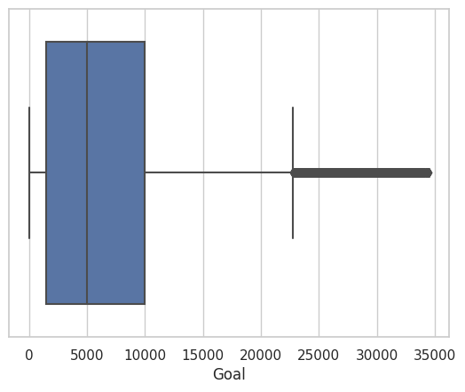

```python
sns.boxplot(data=no_out_goal,x='goal')
sns.set(style="whitegrid")
plt.xlabel(xlabel='Goal')
plt.show()
```

```python
no_out_goal['goal'].mean()
```

```
7223.279325424684
```

```python
df.describe(include='O')
```

|  | category | main_category | currency | state | country |
| --- | --- | --- | --- | --- | --- |
| count | 331465 | 331465 | 331465 | 331465 | 331465 |
| unique | 159 | 15 | 14 | 2 | 22 |
| top | Product Design | Film & Video | USD | failed | United States |
| freq | 18679 | 56504 | 261360 | 197614 | 261360 |

## Let's explore the main categories

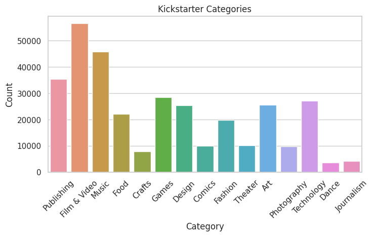

```python
plt.figure(figsize=(8,4))
sns.set(style="whitegrid")
sns.countplot(data=df,x='main_category')
plt.xticks(rotation=45)
plt.xlabel(xlabel='Category')
plt.ylabel(ylabel='Count')
plt.title(label= 'Kickstarter Categories')
plt.show()
```

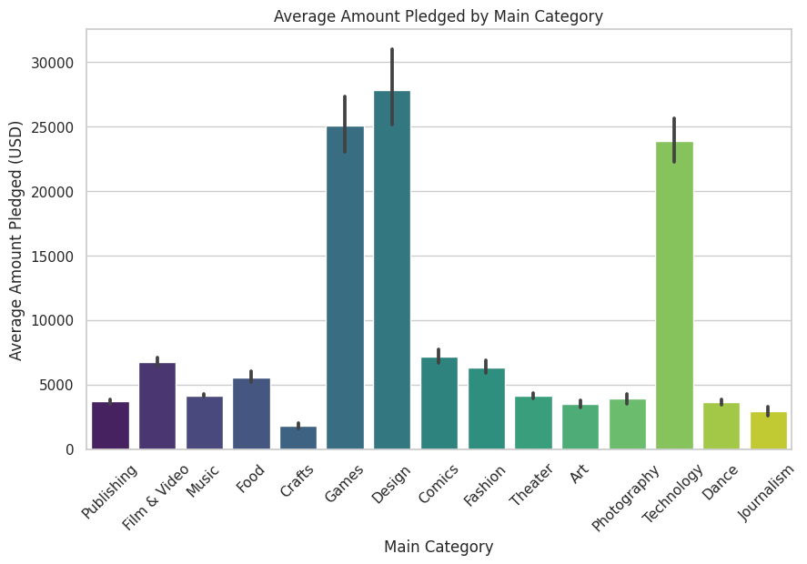

```python
plt.figure(figsize=(10, 6))
sns.set(style="whitegrid")
sns.barplot(data=df,x='main_category', y='usd_pledged_real', palette='viridis')
plt.xlabel('Main Category')
plt.ylabel('Average Amount Pledged (USD)')
plt.title('Average Amount Pledged by Main Category')
plt.xticks(rotation=45)
plt.show()
```

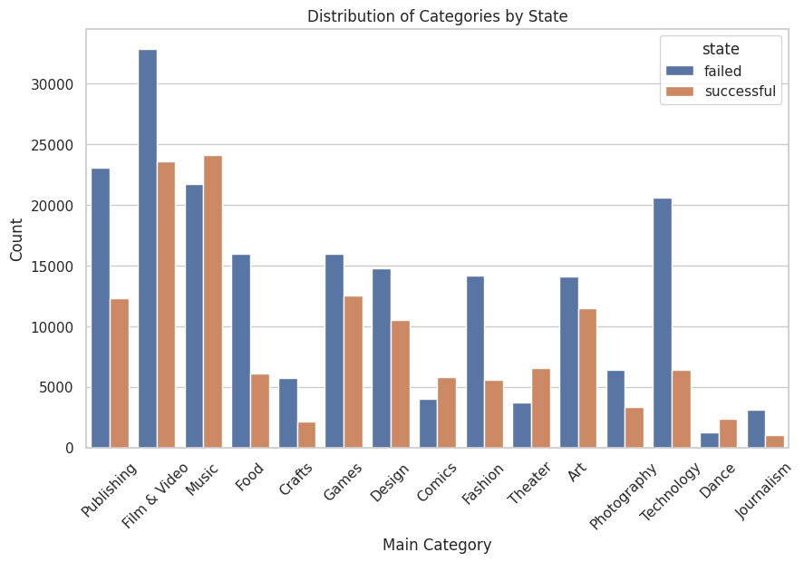

```python
plt.figure(figsize=(10, 6))
sns.set(style="whitegrid")
sns.countplot(data=df,x='main_category',hue='state')
plt.xlabel('Main Category')
plt.ylabel(ylabel='Count')
plt.title(label='Distribution of Categories by State')
plt.xticks(rotation=45)
plt.show()
```

## Explore Distribution of Goal set by project and seperate by 'Successful' and 'Failed'

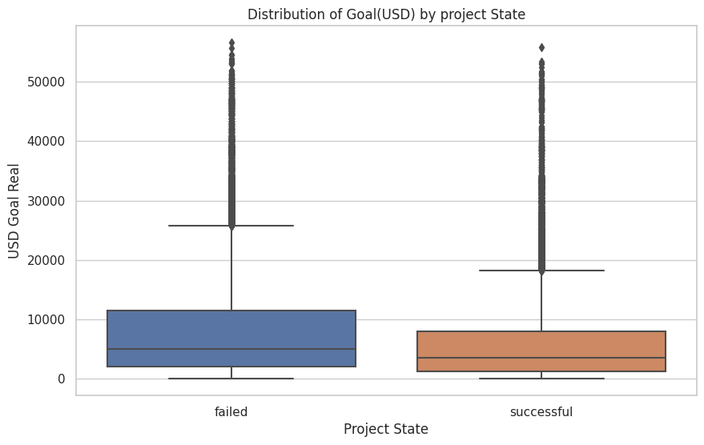

```python
sns.set(style="whitegrid")
plt.figure(figsize=(10, 6))
sns.boxplot(data=no_out_goal,x='state',y='usd_goal_real')
plt.xlabel('Project State')
plt.ylabel('USD Goal Real')
plt.title('Distribution of Goal(USD) by project State')
plt.show()
```

Having a lower goal raises the chance of your project success

## Explore IQR of Backers seperated by 'Successful' and 'Failed'

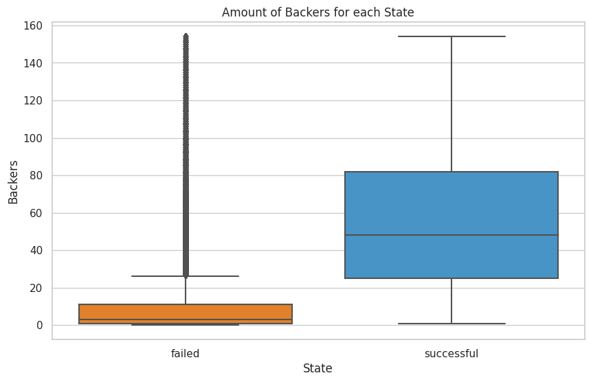

```python
q1 = df['backers'].quantile(0.25)
q3 = df['backers'].quantile(0.75)
iqr = q3 - q1
threshold = 1.5
lower_fence = q1 - threshold * iqr
upper_fence = q3 + threshold * iqr
no_out_backers = df[(df['backers'] > lower_fence) & (df['backers'] < upper_fence)]

sns.set(style="whitegrid")
plt.figure(figsize=(10, 6))
sns.boxplot(data=no_out_backers, x='state', y='backers', palette=['#ff7f0e', '#3498db'])
plt.ylabel(ylabel='Backers')
plt.xlabel(xlabel='State')
plt.title(label='Amount of Backers for each State')
plt.show()
```

Successful projects seem to have more backers. Backers are seemingly important for the success of a project.

## Does a higher amount of backers correlate to more USD pledged?

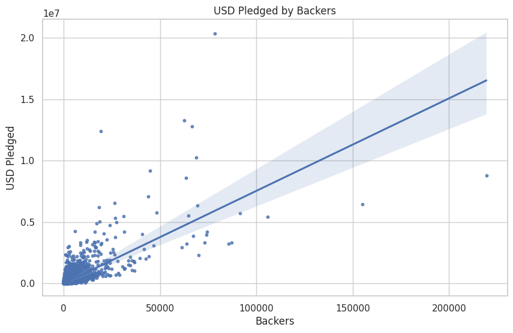

```python
sns.set(style="whitegrid")
plt.figure(figsize=(10, 6))
sns.regplot(data=df,x='backers', y='usd_pledged_real',scatter_kws={'s': 10})
plt.xlabel(xlabel='Backers')
plt.ylabel(ylabel='USD Pledged')
plt.title(label='USD Pledged by Backers')
plt.show()
```

This graph shows a positive correlation between USD pledged and Backers. This means that the more backers there are for a project, then the more USD will be pledged. They have a strong positive correlation.

## Does higher duration of a project equate to more backers?

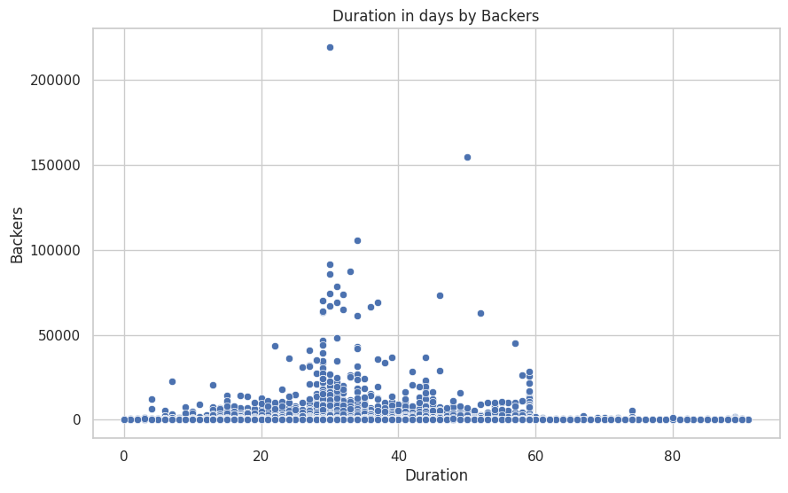

```python
plt.figure(figsize=(10, 6))
sns.scatterplot(data=df,x='Duration', y='backers')
plt.xlabel(xlabel='Duration')
plt.ylabel(ylabel='Backers')
plt.title('Duration in days by Backers')
plt.show()
```

There seems to be little correlation between duration and backer amount

## After sifting through the data and cleaning it, we will now set-up the data to be trained and tested.

```python
outliers = detect_outliers(df, features=numeric_features, n=0)
```

```python
df = df.drop(outliers)
```

```python
df.shape
```

```
(243469, 18)
```

```python
df.head()
```

|  | category | main_category | currency | deadline | goal | launched | pledged | state | backers | country | usd pledged | usd_pledged_real | usd_goal_real | day_launched | month_launched | year_launched | project_duration_days | Duration |
| --- | --- | --- | --- | --- | --- | --- | --- | --- | --- | --- | --- | --- | --- | --- | --- | --- | --- | --- |
| 0 | Poetry | Publishing | GBP | 2015-10-09 | 1000.0 | 2015-08-11 12:12:28 | 0.0 | failed | 0 | United Kingdom | 0.0 | 0.0 | 1533.95 | 11 | 8 | 2015 | 58 | 58 |
| 1 | Narrative Film | Film & Video | USD | 2017-11-01 | 30000.0 | 2017-09-02 04:43:57 | 2421.0 | failed | 15 | United States | 100.0 | 2421.0 | 30000.00 | 2 | 9 | 2017 | 59 | 59 |
| 3 | Music | Music | USD | 2012-04-16 | 5000.0 | 2012-03-17 03:24:11 | 1.0 | failed | 1 | United States | 1.0 | 1.0 | 5000.00 | 17 | 3 | 2012 | 29 | 29 |
| 6 | Food | Food | USD | 2014-12-21 | 1000.0 | 2014-12-01 18:30:44 | 1205.0 | successful | 16 | United States | 1205.0 | 1205.0 | 1000.00 | 1 | 12 | 2014 | 19 | 19 |
| 7 | Drinks | Food | USD | 2016-03-17 | 25000.0 | 2016-02-01 20:05:12 | 453.0 | failed | 40 | United States | 453.0 | 453.0 | 25000.00 | 1 | 2 | 2016 | 44 | 44 |

```python
features = df[['main_category', 'currency', 'usd_pledged_real', 'Duration', 'backers', 'country', 'usd_goal_real']]
```

```python
label = df['state']
```

```python
features = pd.get_dummies(features,columns=['main_category','currency','country'],drop_first=True)
```

```python
label = pd.get_dummies(label,columns=['main_category','currency','country'],drop_first=True)
```

```python
label.head()
```

|  | successful |
| --- | --- |
| 0 | 0 |
| 1 | 0 |
| 3 | 0 |
| 6 | 1 |
| 7 | 0 |

```python
features.head()
```

|  | usd_pledged_real | Duration | backers | usd_goal_real | main_category_Comics | main_category_Crafts | main_category_Dance | main_category_Design | main_category_Fashion | main_category_Film & Video | ... | country_Mexico | country_Netherlands | country_New Zealand | country_Norway | country_Singapore | country_Spain | country_Sweden | country_Switzerland | country_United Kingdom | country_United States |
| --- | --- | --- | --- | --- | --- | --- | --- | --- | --- | --- | --- | --- | --- | --- | --- | --- | --- | --- | --- | --- | --- |
| 0 | 0.0 | 58 | 0 | 1533.95 | 0 | 0 | 0 | 0 | 0 | 0 | ... | 0 | 0 | 0 | 0 | 0 | 0 | 0 | 0 | 1 | 0 |
| 1 | 2421.0 | 59 | 15 | 30000.00 | 0 | 0 | 0 | 0 | 0 | 1 | ... | 0 | 0 | 0 | 0 | 0 | 0 | 0 | 0 | 0 | 1 |
| 3 | 1.0 | 29 | 1 | 5000.00 | 0 | 0 | 0 | 0 | 0 | 0 | ... | 0 | 0 | 0 | 0 | 0 | 0 | 0 | 0 | 0 | 1 |
| 6 | 1205.0 | 19 | 16 | 1000.00 | 0 | 0 | 0 | 0 | 0 | 0 | ... | 0 | 0 | 0 | 0 | 0 | 0 | 0 | 0 | 0 | 1 |
| 7 | 453.0 | 44 | 40 | 25000.00 | 0 | 0 | 0 | 0 | 0 | 0 | ... | 0 | 0 | 0 | 0 | 0 | 0 | 0 | 0 | 0 | 1 |

5 rows × 50 columns

```python
s = StandardScaler()
columns_to_normalize = ['usd_pledged_real', 'Duration', 'backers','usd_goal_real']
features[columns_to_normalize] = s.fit_transform(features[columns_to_normalize])
features.head()
```

|  | usd_pledged_real | Duration | backers | usd_goal_real | main_category_Comics | main_category_Crafts | main_category_Dance | main_category_Design | main_category_Fashion | main_category_Film & Video | ... | country_Mexico | country_Netherlands | country_New Zealand | country_Norway | country_Singapore | country_Spain | country_Sweden | country_Switzerland | country_United Kingdom | country_United States |
| --- | --- | --- | --- | --- | --- | --- | --- | --- | --- | --- | --- | --- | --- | --- | --- | --- | --- | --- | --- | --- | --- |
| 0 | -0.696002 | 1.952585 | -0.753840 | -0.657153 | 0 | 0 | 0 | 0 | 0 | 0 | ... | 0 | 0 | 0 | 0 | 0 | 0 | 0 | 0 | 1 | 0 |
| 1 | 0.491308 | 2.029057 | -0.269126 | 3.421699 | 0 | 0 | 0 | 0 | 0 | 1 | ... | 0 | 0 | 0 | 0 | 0 | 0 | 0 | 0 | 0 | 1 |
| 3 | -0.695511 | -0.265108 | -0.721526 | -0.160508 | 0 | 0 | 0 | 0 | 0 | 0 | ... | 0 | 0 | 0 | 0 | 0 | 0 | 0 | 0 | 0 | 1 |
| 6 | -0.105044 | -1.029829 | -0.236812 | -0.733661 | 0 | 0 | 0 | 0 | 0 | 0 | ... | 0 | 0 | 0 | 0 | 0 | 0 | 0 | 0 | 0 | 1 |
| 7 | -0.473841 | 0.881975 | 0.538730 | 2.705258 | 0 | 0 | 0 | 0 | 0 | 0 | ... | 0 | 0 | 0 | 0 | 0 | 0 | 0 | 0 | 0 | 1 |

5 rows × 50 columns

```python
label = np.ravel(label)
```